# A Little Example Using Vintage Sparse PCA on Semantic Scholar Dataset

Xiaotian Wang, Ying Chen

11/9/2020

### Background and Data

Full data can be found [here](http://s2-public-api-prod.us-west-2.elasticbeanstalk.com/corpus/).

The main purpose is to explore the features of papers using or mentioning LASSO. We use the semantic scholar dataset, which provides detailed information on research papers. The huge dataset gives us a chance to explore publishing pattern. we use LASSO as key word, journal names as variable of interest. We bring in title, abstract, year published, and journal name of each paper. The r codes to get data are as belows. Every record in each raw data file is searched. If the record contains 'LASSO' (not case sensitive), the information we need will be stored in a separate spreadsheet. We put all .csv spreadsheet in the data folder.

```r
library(data.table)
library(tidyverse)
library(tidytext)
library(Matrix)
library(vsp)
```

```r
library(tidyverse)
source("code/getData.R")

includeLine = function(x) {
  if(nchar(x$paperAbstract) == 0) return(F)
  grepl("lasso", x$paperAbstract,ignore.case = TRUE)
}

processLine = function(x) tibble(title = x$title,
                                 abstract = x$paperAbstract,
                                 year = x$year,
                                 journal = x$journalName)
outputPath = "LASSO"

processDataFiles(includeLine, processLine, outputPath)

dat = pullDataFiles(outputPath)
```

We read the data line by line, and decide whether to process the line by the includeLine function. For getData function, it can be found here, and here.

### Data Exploration

Now we have all research papers that mentioned 'LASSO' in abstract. Let's take a look on them.

```r
rm(list = ls())
filenames = list.files("data/LASSO")
data = data.frame()
for(name in filenames)
{
  temp = read.csv(paste("data/LASSO/",name,sep=''))
  data = rbind(data,temp)
}
# Delete the date with missing journal
data<-data[data$journal!="",]

str(data)
```

```
## 'data.frame':    9904 obs. of  4 variables:
##  $ title   : chr  "Comparison of statistical methods for finding network motifs" "Parametric component detection and variable selection in varying-coefficient partially linear models" "The comparative morphology of hepatic photophores in decapod Crustacea" "Predicting later asthma in toddlers: Do…
##  $ abstract: chr  "Abstract There has been much recent interest in systems biology for investigating the structure of gene regulat"| __truncated__ "In this paper we are concerned with detecting the true structure of a varying-coefficient partially linear mode"| __truncated__ "The hepatic photopho…
##  $ year    : int  2014 2012 1981 2013 2018 2014 2016 2015 2019 2017 ...
##  $ journal : chr  "Statistical Applications in Genetics and Molecular Biology" "J. Multivar. Anal." "Journal of the Marine Biological Association of the United Kingdom" "European Respiratory Journal" ...
```

```r
freq<-data %>% group_by(journal) %>% mutate(Frequency=n())
freq %>% arrange(desc(Frequency))  %>% distinct(journal, Frequency) %>%
  filter(Frequency>50)
```

```
## # A tibble: 9 x 2
## # Groups:   journal [9]
##   journal                                                           Frequency
##   <chr>                                                                 <int>
## 1 ArXiv                                                                   290
## 2 arXiv: Methodology                                                      160
## 3 arXiv: Statistics Theory                                                153
## 4 PLoS ONE                                                                126
## 5 bioRxiv                                                                  82
## 6 Scientific Reports                                                       64
## 7 International journal of systematic and evolutionary microbiology        62
## 8 Comput. Stat. Data Anal.                                                 60
## 9 arXiv: Machine Learning                                                  57
```

Next, instead of viewing each abstract as a whole object, we get words out of the text. By doing so, we are able to see if these papers have anything in common.

### Factors

Based on the paper-word pair, we create a matrix with paper ID as row and each word as column. Then, we try the vsp package to see if there are any factors standing out.

```r
text_df <- tibble(paper = 1:nrow(data), abstract = data$abstract)
tt  = text_df %>% unnest_tokens(word, abstract)
A = cast_sparse(tt, paper, word)
str(A)
```

```
## Formal class 'dgCMatrix' [package "Matrix"] with 6 slots
##   ..@ i       : int [1:1326530] 0 5 54 63 73 76 82 85 106 121 ...
##   ..@ p       : int [1:124136] 0 837 2004 4520 6646 7128 7809 8319 17375 17864 ...
##   ..@ Dim     : int [1:2] 9904 124135
##   ..@ Dimnames:List of 2
##   .. ..$ : chr [1:9904] "1" "2" "3" "4" ...
##   .. ..$ : chr [1:124135] "abstract" "there" "has" "been" ...
##   ..@ x       : num [1:1326530] 1 1 1 1 1 1 1 1 1 1 ...
##   ..@ factors : list()
```

```r
dim(A)
```

```
## [1]   9904 124135
```

```r
cs = colSums(A)

fa = vsp(A, rank = 3)
fa
```

```
## Vintage Sparse PCA Factor Analysis
##
## Rows (n):   9904
## Cols (d):   124135
## Factors (rank): 3
## Lambda[rank]:   0.3827
##
## Pre-Processing Options (TODO)
##
## Components
##
## Z: 9904 x 3 [dgeMatrix]
## B: 3 x 3 [dgeMatrix]
## Y: 124135 x 3 [dgeMatrix]
## u: 9904 x 3 [matrix]
## d: 3      [numeric]
## v: 124135 x 3 [matrix]
```

```r
abstract = text_df$abstract
```

We do the clustering on the paper-word matrix with rank 3, and see what will happen.

```r
topPapers = 5

topDoc = fa$Z %>%
  apply(2,
        function(x) which(rank(-x, ties.method = "random") <= topPapers)
  )
for(j in 1:ncol(topDoc)){
  paste("topic", j, "\n \n") %>% cat
  data$title[topDoc[,j]] %>% print
  paste("\n \n \n") %>% cat
}
```

```
## topic 1
##
## [1] "Generation of disease-specific induced pluripotent stem cells from Alzheimer's disease patients"
## [2] "Size matters: network inference tackles the genome scale"
## [3] "Community Health Clubs for Water, Sanitation and Hygiene (WASH) improvement in Rural Burkina Faso"
## [4] "tert-Butylhydroquinone protects dopaminergic neurons from MPP+ cytotoxicity primarily via normalization of glutathione levels in midbrain slice cultures"
## [5] "Comparative Effectiveness and Safety of Bariatric Procedures for Weight Loss"
##
##
##
## topic 2
##
## [1] "RÃƒÂ©cupÃƒÂ©ration clinico-radiologique dÃ¢â‚¬â„¢un syndrome dÃ¢â‚¬â„¢embolie graisseuse cÃƒÂ©rÃƒÂ©brale chez un patient drÃƒÂ©panocytaire"
## [2] "LÃ¢â‚¬â„¢endoscopie de lÃ¢â‚¬â„¢intestin grÃƒÂªle en 1992: est-ce la fin du tunnel?"
## [3] "Study of mosaic glasses from the Alpha Basilica (sixth century) of Nikopolis in Epirus, Greece"
## [4] "Une mÃƒÂ©thode de lutte gÃƒÂ©nÃƒÂ©tique contre Anopheles gambiae Giles, 1902"
## [5] "Choosing an appropriate alliance governance mode: The role of institutional, cultural and geographical distance in international research & development (R&D) collaborations"
##
##
##
## topic 3
##
## [1] "Ãƒâ\200“kologische Untersuchungen ÃƒÂ¼ber die Terrestrische Arthropodenfauna im Anwurf Mariner Algen"
## [2] "Contributo allo studio della capacitÃƒÂ  evolutiva dei due primi blastomeri nell' uovo di tritone (triton cristatus)"
## [3] "Ueber Krankenthermometer (Schluss aus No. 3.)"
## [4] "InfertilitÃƒÂ¤t: Ist dem Mann zu helfen?"
## [5] "Tschuschke V (2011) Psychoonkologie. Psychologische Aspekte der Entstehung und BewÃƒÂ¤ltigung von Krebs"
##
##
##
```

Looking at the top five papers in each clusters, we can see that the titles of the papers are gathered by the languages.

For the first cluster, they are mostly English paper, and for the 2nd and 3rd, they are French and German.

Note: although some titles of papers in cluster 2 look like they are English paper, in fact their abstracts are of different languages.

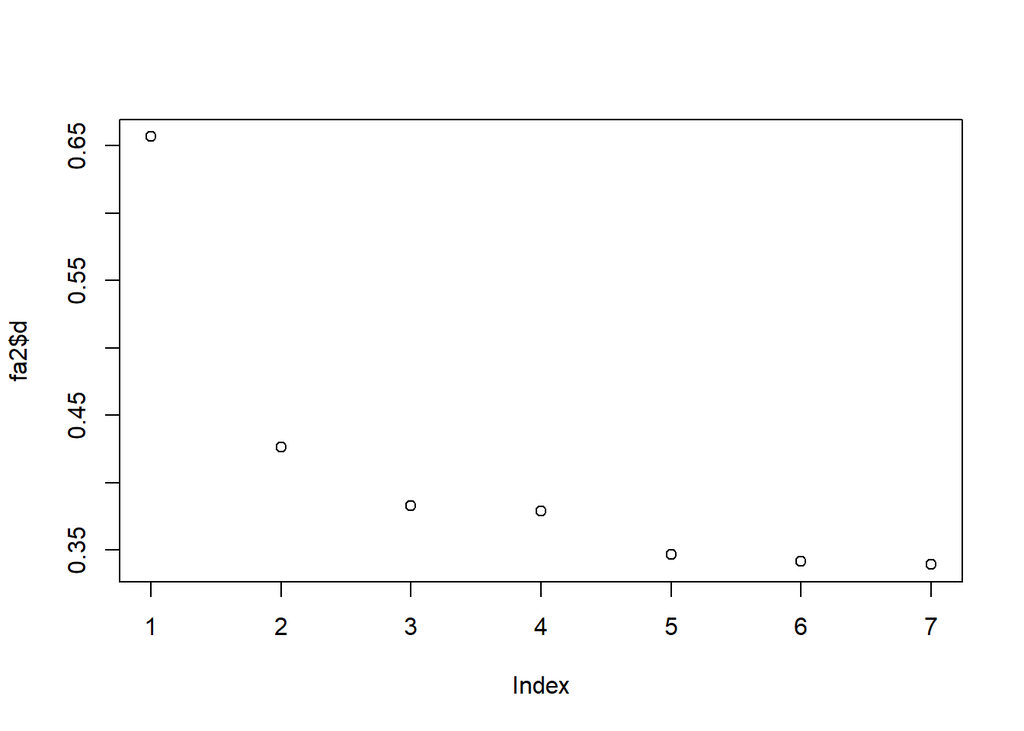

```r
fa2 = vsp(A, rank = 7)
plot(fa2$d)
```

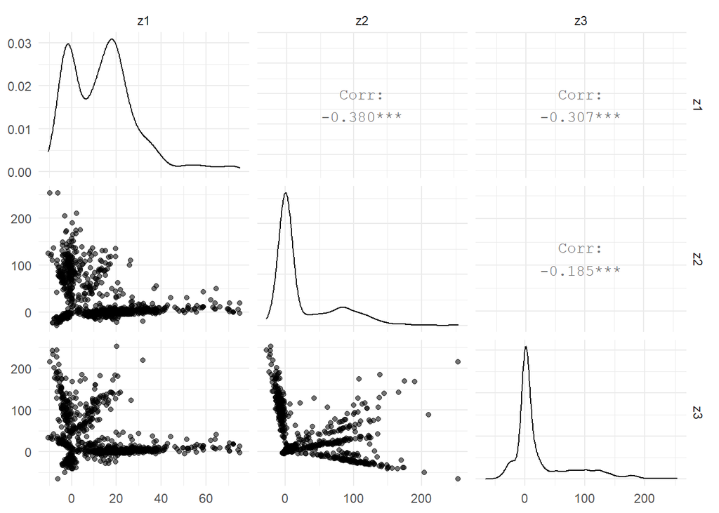

```r
plot_varimax_z_pairs(fa, 1:3)
```

From the plot above, we may conclude that there are some papers with more than one abstracts which are of different languages(just like the papers appearing in cluster 2).

We now see the best feature functions

```r
bff(fa$Z,A,6) %>% print
```

```
##      [,1]   [,2]  [,3]
## [1,] "to"   "la"  "und"
## [2,] "of"   "un"  "die"
## [3,] "for"  "le"  "der"
## [4,] "the"  "les" "von"
## [5,] "and"  "de"  "eine"
## [6,] "with" "une" "den"
```

We can see that for these clusters, the results are the commonly used words in English, French and German seperately.

### Attempts on the Analysis on English-only Papers

From the above result, papers are clustered together by different languages. Then, what if we focus only on one language? As most papers are in English, we repeat the similar analysis among papers in English.

We can use the new includeLine function

```r
includeLine = function(x) {
  if(nchar(x$paperAbstract) == 0) return(F)
  grepl("lasso", x$paperAbstract,ignore.case = TRUE)&grepl("regression", x$paperAbstract,ignore.case = TRUE)
}
```

The new includeLine rule becomes we process the line only when it includes the keywords LASSO and the commenly used English word "regression"" in the technical papers mentioning LASSO.

```r
filenames = list.files("data/LASSOreg")
data = data.frame()
for(name in filenames)
{
  temp = read.csv(paste("data/LASSOreg/",name,sep=''))
  data = rbind(data,temp)
}

str(data)
```

```
## 'data.frame':    4190 obs. of  4 variables:
##  $ title   : chr  "Predicting later asthma in toddlers: Do environmental exposure data improve a clinical tool?" "Factors related to and economic implications of inhospital death in German lung cancer patients - results of a "| __truncated__ "Ultrahigh dimensional variable selection through the p…
##  $ abstract: chr  "Background: We recently developed a simple clinical tool for predicting asthma at school-age in toddlers presen"| __truncated__ "BackgroundWhen patients die in a hospital their quality of life is lower than when they die at home or in a hos"| __truncated__ "Abstract The penaliz…
##  $ year    : int  2013 2018 2014 2009 2019 2018 2019 2018 2016 2014 ...
##  $ journal : chr  "European Respiratory Journal" "BMC Health Services Research" "Statistical Papers" "" ...
```

```r
# Delete the date with missing journal
# data<-data[data$journal!="",]


text_df <- tibble(paper = 1:nrow(data), abstract = data$abstract)
tt  = text_df %>% unnest_tokens(word, abstract)
A = cast_sparse(tt, paper, word)
str(A)
```

```
## Formal class 'dgCMatrix' [package "Matrix"] with 6 slots
##   ..@ i       : int [1:563177] 0 4 18 49 60 71 103 116 134 153 ...
##   ..@ p       : int [1:39876] 0 338 3226 3443 4029 8029 8294 8889 9154 12741 ...
##   ..@ Dim     : int [1:2] 4190 39875
##   ..@ Dimnames:List of 2
##   .. ..$ : chr [1:4190] "1" "2" "3" "4" ...
##   .. ..$ : chr [1:39875] "background" "we" "recently" "developed" ...
##   ..@ x       : num [1:563177] 1 1 1 1 1 1 1 1 1 1 ...
##   ..@ factors : list()
```

```r
dim(A)
```

```
## [1]  4190 39875
```

```r
# hist(rowSums(A))
# cs = colSums(A)
#hist(log(cs[cs>1]))


library(vsp)
fa = vsp(A, rank = 4)

abstract = text_df$abstract


topPapers = 5
# just run the next code chunk...

topDoc = fa$Z %>%
  apply(2,
        function(x) which(rank(-x, ties.method = "random") <= topPapers)
  )
for(j in 1:ncol(topDoc)){
  paste("topic", j, "\n \n") %>% cat
  data$title[topDoc[,j]] %>% print
  paste("\n \n \n") %>% cat
}
```

```
## topic 1
##
## [1] "Positive graphical lasso estimation of sparse inverse covariance matrices"
## [2] "Kernel Learning: Automatic Selection of Optimal Kernels"
## [3] "Studies in the econometrics of panel data with applications to"
## [4] "Size matters: network inference tackles the genome scale"
## [5] "Title: Contextual MDPs: A New Model and PAC Guarantees for Reinforcement Learning with Rich Observations"
##
##
##
## topic 2
##
## [1] "Introducing complex dependency structures into supervised components-based models"
## [2] "Nouvelle mÃƒÂ©thode bayÃƒÂ©sienne de sÃƒÂ©lection de variables pour des ÃƒÂ©chantillons de petite taille incorporant lÃ¢â‚¬â„¢expertise clinique. Application au cancer colorectal"
## [3] "Approches pÃƒÂ©nalisÃƒÂ©es et autres dÃƒÂ©veloppements statistiques pour l'ÃƒÂ©pidÃƒÂ©miologie"
## [4] "Les facteurs clÃƒÂ©s de succÃƒÂ¨s des projets d'aide au dÃƒÂ©veloppement"
## [5] "Structures de dÃƒÂ©pendance complexes pour modÃƒÂ¨les ÃƒÂ  composantes supervisÃƒÂ©es"
##
##
##
## topic 3
##
## [1] "References"
## [2] "AF Ablation ITarget of ablation of peri-mitral flutter: mitral valve isthmus or triggers?Comparison of sensitivity of transthoracic, transoesophageal, and intracardiac echocardiography for guiding transeptal puncturePulmonary antrum radial-linear ablation: a new therapy for atrial fibrillati…
## [3] "P1049: Non-REM sleep microstructures and phasic REM sleep events are associated with intracranial oxygenation changes measured with NIRS"
## [4] "Different Role of Left Atrial Size and Function in Patients with Paroxysmal versus Persistent Atrial Fibrillation"
## [5] "P1048: Increased amount of reported total sleep time during 24 hours is related to the severity of sleep disturbances in ischemic stroke patients"
##
##
##
## topic 4
##
## [1] "Analysis of Energy Consumption Influencing Factors in China Based on the Lasso Method"
## [2] "Elastic NetÃ§Â½Â°Ã¥â\200°â\200¡Ã£Â\201Â«Ã£â\200šË†Ã£â\200šâ\200¹Ã£Æ’Â«Ã£Æ’Â¼Ã£Æ’Â«Ã£Æ’Â»Ã£â\200šÂ¢Ã£Æ’Â³Ã£â\200šÂµÃ£Æ’Â³Ã£Æ’â\200“Ã£Æ’Â«Ã¦Â³â\200¢Ã£Â\201Â¨Ã£Â\201Â\235Ã£Â\201Â®Ã¥Â¿Å“Ã§â\200\235Â¨"
## [3] "Ã¥Å¸ÂºÃ¤ÂºÅ½LassoÃ¦â\200“Â¹Ã¦Â³â\200¢Ã¤Â¸Å½LogisticÃ¥â\200ºÅ¾Ã¥Â½â\200\231Ã§Å¡â\200žÃ¤Â¸Å Ã¥Â¸â\200šÃ¥â\200¦Â¬Ã¥Â\217Â¸Ã¨Â´Â¢Ã¥Å Â¡Ã©Â¢â\200žÃ¨ÂÂ¦Ã¥Ë†â\200 Ã¦Å¾Â\220 The Financial Early Warning Model of Listed Companies Based on Lasso Method and Logistic Regression"
## [4] "Analysis of Influencing Factors of Fiscal Revenue in Zhejiang Province Based on Data Mining Technology"
## [5] "Analysis the Influence Factors of Steel Demand in China"
##
##
##
```

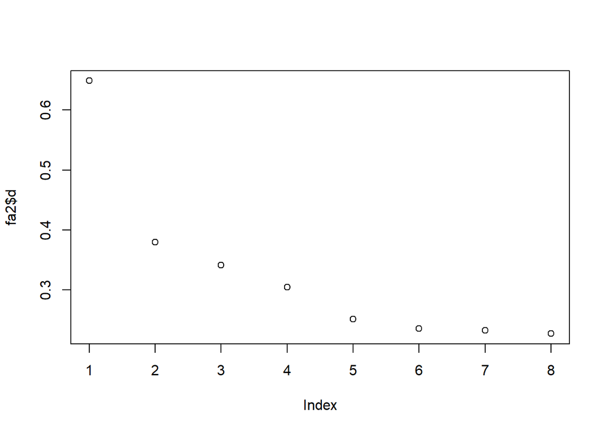

```r
fa2 = vsp(A, rank = 8)

plot(fa2$d)
```

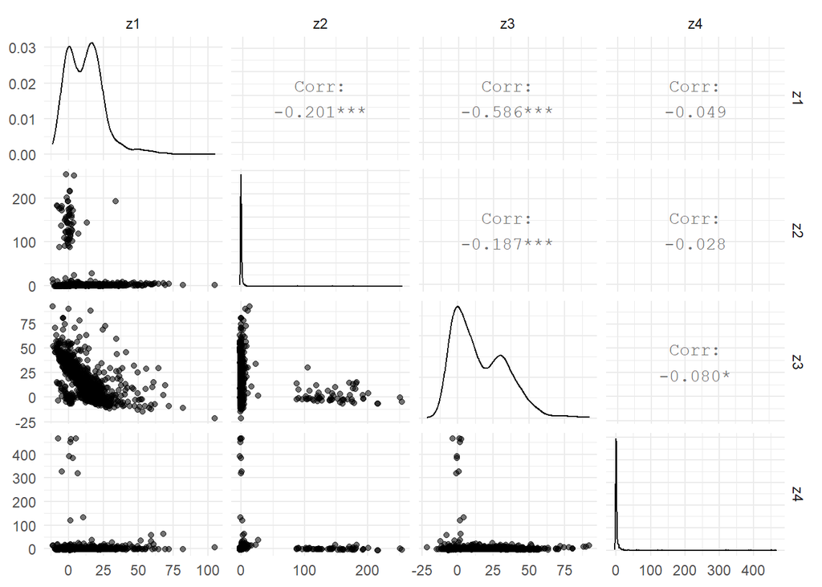

```r
plot_varimax_z_pairs(fa, 1:4)
```

```r
bff(fa$Z,A,6) %>% print
```

```
##      [,1]       [,2]  [,3]         [,4]
## [1,] "paper"    "de"  "were"       "偓"
## [2,] "linear"   "la"  "patients"   "聛"
## [3,] "problem"  "des" "was"        "懊"
## [4,] "propose"  "une" "clinical"   "搂"
## [5,] "sparse"   "les" "95"         "赂"
## [6,] "sparsity" "le"  "identified" "犆"
```

We try to get rid of the influence from different language and instead, wish to find out the clusters from different technical topics. However the influence from the language still exists. As we mentioned before, there are some papers with more than one abstracts which are of different language. As a result, we can see our result this time that it can show the factors from both technical toplics and language.

From the bff results, we can see that for cluster 1, they show some statistical features from the word like "linear" and "sparsity", while in cluster 3, there are some words like "patients" and "clinical" from medicine.

However, for cluster 2 and 4, they are still some words from different language.(Note: the bff results from cluster 4 are in fact some Chinese characters from Unicode). So we still can not get rid of the influence from different language thoroughly.